# Effectiveness of COVID-19 Booster doses in England: a sequential trials study in OpenSAFELY: Supplementary materials

# COVID-19 vaccination history

The dates and brands of any COVID-19 vaccines administered as part of the national roll-out (e.g., excluding in vaccine trials and vaccines administered abroad) are available in the primary care records via transfer from the National Immunisation Management System (NIMS). Vaccine cardinality (dose 1, dose 2, …) is determined by vaccination dates alone. We cannot distinguish between “third” doses in immunosuppressed or otherwise vulnerable people which were administered ahead of the national booster roll-out, and “booster” doses, i.e., indication for 3rd vaccine dose. However, we match on characteristics that approximate determinants of third dose vaccination, and the recruitment period excludes a majority of early third dose recipients.

# Matching details

Booster eligibility was dependent on vaccine priority group, largely determined by clinical vulnerability and age. Booster doses were initially available 6 months after administration of the second dose, later reduced to 3 months following concerns over the surge in cases and the emergence of the seemingly more transmissible Omicron variant. Determining vaccine eligibility for a given person on a given day is therefore complex. To avoid these complexities, we determined trial eligibility for each person on each day of recruitment by ensuring that there were sufficiently many people with similar characteristics who were being vaccinated on that day. Specifically, a rolling weekly average was calculated within strata defined by region, priority group, and week of second vaccine dose. If fewer than 50 people had been vaccinated within each strata on each day, then that strata was not eligible for recruitment on that day.

The Joint Committee on Vaccine and Immunisation (JCVI) priority groups were defined as follows:

| Priority group | Description |
| --- | --- |
| 1 | Residents in a care home for older adults Staff working in care homes for older adults |
| 2 | All those 80 years of age and over Frontline health and social care workers |
| 3 | All those 75-79 years of age |
| 4 | All those 70-74 years of age Individuals aged 16-69 in a high risk group |
| 5 | All those 65-69 years of age |
| 6 | Adults aged 16-64 years in an at-risk group |
| 7 | All those 60-64 years of age |
| 8 | All those 55-59 years of age |
| 9 | All those 50-54 years of age |
| 10a | All those 40-49 years of age |
| 10b | All those 18-39 years of age |

See original priority groups here: https://assets.publishing.service.gov.uk/government/uploads/system/uploads/attachment_data/file/1007737/Greenbook_chapter_14a_30July2021.pdf#page=15 See revised priority groups here: https://www.england.nhs.uk/coronavirus/wp-content/uploads/sites/52/2021/07/C1327-covid-19-vaccination-autumn-winter-phase-3-planning.pdf

Note that we excluded care home residents and health care workers in our analysis, so members of JCVI group 1 are not included and JCVI group 2 includes only those aged 80 and over. The original priority group list has 9 groups, with a 10th group implicitly defined as “everybody else”. Here we explicitly define this group, and split into two (10a and 10b) because of the earlier booster eligiblity in the 40-49 group from 15 November 2021 onwards. (https://www.gov.uk/government/news/jcvi-issues-advice-on-covid-19-booster-vaccines-for-those-aged-40-to-49-and-second-doses-for-16-to-17-year-olds)

# Variables and codelists

[output not shown]

Codelists can be found at `https://codelists.opensafely.org/codelist/<ID>`, substituting `<ID>` for the codelist identifier in the table above.

#### Table S1: Characteristics of candidate participants

Candidate matching characteristics as on the day of recruitment into the treatment or control group.

| Characteristic | Boosted, eligible, matched | Control |
| --- | --- | --- |
| Total N | 3,426,960 | 3,426,960 |
| Primary vaccine course |  |  |
| BNT162b2-BNT162b2 | 1,476,131 (43%) | 1,476,131 (43%) |
| ChAdOx1-ChAdOx1 | 1,950,829 (57%) | 1,950,829 (57%) |
| Age |  |  |
| 18-39 | 184,832 (5.4%) | 199,354 (5.8%) |
| 40-49 | 221,668 (6.5%) | 242,618 (7.1%) |
| 50-59 | 628,035 (18%) | 632,212 (18%) |
| 60-69 | 939,494 (27%) | 932,775 (27%) |
| 70-79 | 1,039,938 (30%) | 1,011,653 (30%) |
| 80-89 | 364,261 (11%) | 351,385 (10%) |
| 90+ | 48,732 (1.4%) | 56,963 (1.7%) |
| Sex |  |  |
| Female | 1,860,622 (54%) | 1,865,153 (54%) |
| Male | 1,566,338 (46%) | 1,561,807 (46%) |
| Ethnicity |  |  |
| White | 3,218,953 (94%) | 3,195,436 (93%) |
| Black | 31,058 (0.9%) | 37,879 (1.1%) |
| South Asian | 126,998 (3.7%) | 145,055 (4.2%) |
| Mixed | 18,073 (0.5%) | 19,164 (0.6%) |
| Other | 31,878 (0.9%) | 29,426 (0.9%) |
| IMD |  |  |
| 1 most deprived | 469,397 (14%) | 558,365 (16%) |
| 2 | 586,546 (17%) | 641,493 (19%) |
| 3 | 763,813 (22%) | 775,775 (23%) |
| 4 | 799,431 (23%) | 750,914 (22%) |
| 5 least deprived | 807,773 (24%) | 700,413 (20%) |
| Region |  |  |
| North East and Yorkshire | 616,628 (18%) | 616,628 (18%) |
| Midlands | 774,777 (23%) | 774,777 (23%) |
| North West | 285,853 (8.3%) | 285,853 (8.3%) |
| East of England | 825,941 (24%) | 825,941 (24%) |
| London | 109,498 (3.2%) | 109,498 (3.2%) |
| South East | 261,876 (7.6%) | 261,876 (7.6%) |
| South West | 552,387 (16%) | 552,387 (16%) |
| Clinically extremely vulnerable | 470,981 (14%) | 470,981 (14%) |
| Body Mass Index > 40 kg/m^2 | 156,646 (4.6%) | 164,724 (4.8%) |
| Chronic heart disease | 665,488 (19%) | 659,164 (19%) |
| Chronic kidney disease | 316,348 (9.2%) | 315,120 (9.2%) |
| Diabetes | 532,340 (16%) | 562,011 (16%) |
| Chronic liver disease | 115,145 (3.4%) | 121,472 (3.5%) |
| Chronic respiratory disease | 249,441 (7.3%) | 252,359 (7.4%) |
| Asthma | 25,437 (0.7%) | 24,184 (0.7%) |
| Chronic neurological disease | 274,335 (8.0%) | 292,425 (8.5%) |
| Immunosuppressed | 154,260 (4.5%) | 121,969 (3.6%) |
| Asplenia or poor spleen function | 40,134 (1.2%) | 36,303 (1.1%) |
| Learning disabilities | 21,039 (0.6%) | 26,533 (0.8%) |
| Serious mental illness | 31,996 (0.9%) | 42,422 (1.2%) |
| Number of SARS-CoV-2 tests |  |  |
| 0 | 2,092,836 (61%) | 2,217,161 (65%) |
| 1 | 486,362 (14%) | 467,274 (14%) |
| 2 | 206,142 (6.0%) | 193,982 (5.7%) |
| 3+ | 641,620 (19%) | 548,543 (16%) |
| Prior documented SARS-CoV-2 infection | 202,432 (5.9%) | 202,432 (5.9%) |
| In hospital (planned admission) | 46,478 (1.4%) | 46,421 (1.4%) |

#### Figure S1: Booster uptake and matching success

Cumulative booster vaccination over the duration of the study period, by matching eligibility and matching success.

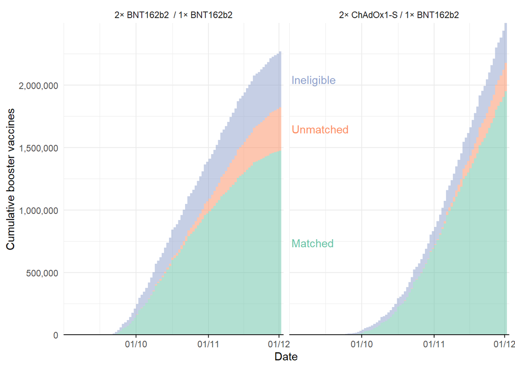

### Figure S2: Standardised Mean Differences between Boosted and Unboosted groups

For variables that were matched exactly the SMD is zero, and so are not shown.

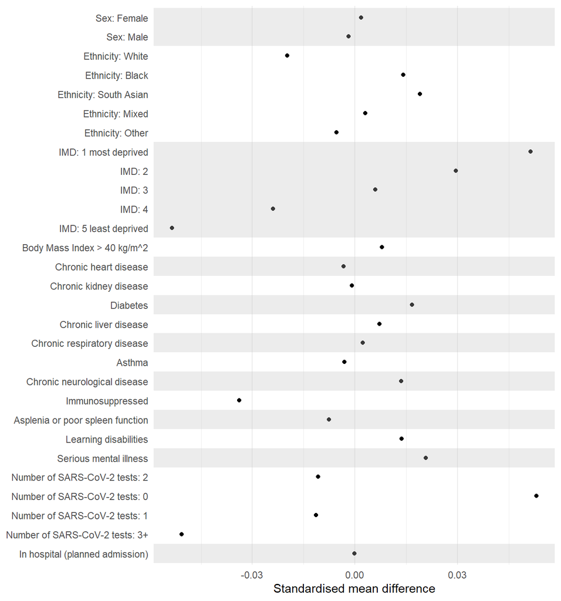

## Figure S3: Estimated booster effectiveness, all models

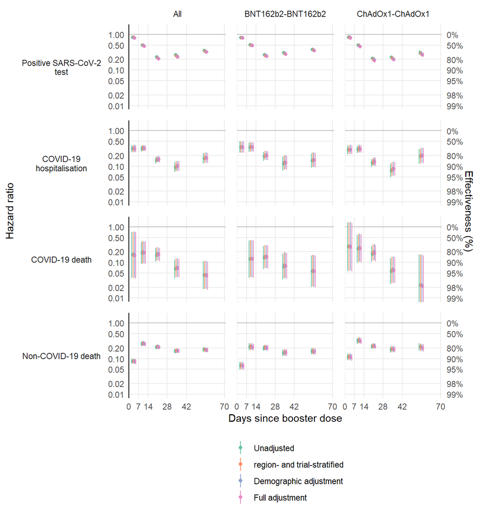